# Test Harvest Control Rule

Sarah Gaichas

2026-08-14

# Code taken from the SPASM.MSE vignettes [here](https://lichengxue.github.io/SPASAM.MSE/index.html)

Starting with this one https://lichengxue.github.io/SPASAM.MSE/Harvest-Control-Rule.html

And modifying to test the addition of the MAFMC risk policy and ABC HCR to `SPASAM.MSE::advice_fn()`

First run the code as is

## Operating model setup

### Basic information

```r
year_start  <- 1
year_end    <- 20
MSE_years   <- 3

info <- generate_basic_info(
  n_stocks = 2,
  n_regions = 2,
  n_indices = 2,
  n_fleets = 2,
  n_seasons = 1,
  base.years = year_start:year_end,
  n_feedback_years = MSE_years,
  life_history = "medium",
  n_ages = 12
)
```

```
##
##   --------------------
##
##   IMPORTANT!!!!
##
##   For the current version of WHAM, if WAA pointers are specified (i.e., WAA differs across fleets, indices, or stocks),
##
##   they need to be updated *after* prepare_wham_input(). Otherwise, a global WAA will be applied to all components.
##
##   --------------------
##
```

```
##
##   --------------------
##   IMPORTANT!!!!
##
##   For the current version of WHAM:
##
##   - If CV and effective sample size for **catch** vary over years,
##   or if some years have missing aggregate or age composition data for **catch**,
##   you must update these inputs *after* prepare_wham_input()
##   using the update_input_catch_info() function.
##
##   - If CV and effective sample size for **indices** vary over years,
##   or if some years have missing aggregate or age composition data for **indices**,
##   you must update these inputs *after* prepare_wham_input()
##   using the update_input_index_info() function.
##
##   Otherwise, WHAM will assume constant CV/sample size and complete data across all years.
##   --------------------
##
```

```r
basic_info = info$basic_info
catch_info = info$catch_info
index_info = info$index_info
F_info     = info$F
```

### Specify movement

```r
basic_info <- generate_NAA_where(basic_info, move.type = 2)
move <- generate_move(
  basic_info = basic_info,
  move.type = 2,
  move.rate = c(0.3, 0.1),
  move.re = "constant"
)
```

```
##
## Note: Movement rate is assumed to be region-specific regardless of stock!
##
## All stocks 'can' move
##
## Movement rate for stocks in region 1 is 0.3
##
## Movement rate for stocks in region 2 is 0.1
##
## Movement is assumed at a constant rate without random effects
```

### Configure selectivity

```r
n_stocks  <- as.integer(basic_info['n_stocks'])
n_regions <- as.integer(basic_info['n_regions'])
n_fleets  <- as.integer(basic_info['n_fleets'])
n_indices <- as.integer(basic_info['n_indices'])
n_ages    <- as.integer(basic_info['n_ages'])

fleet_pars <- c(5, 1)
index_pars <- c(2, 1)
sel <- list(
  model = rep("logistic", n_fleets + n_indices),
  initial_pars = c(rep(list(fleet_pars), n_fleets), rep(list(index_pars), n_indices))
)
```

### Configure NAA

```r
sigma      <- "rec+1"
re_cor     <- "iid"
ini.opt    <- "equilibrium"
Rec_sig    <- 0.5
NAA_sig    <- 0.2

sigma_vals <- array(NAA_sig, dim = c(n_stocks, n_regions, n_ages))
sigma_vals[,,1] <- Rec_sig

log_N1    <- rep(10, n_stocks)
log_N1[1] <- log(exp(10) * 2)
N1_pars   <- generate_ini_N1(basic_info, ini.opt, log_N1)

mean_rec_par <- lapply(1:n_stocks, function(i) exp(log_N1[i]))

NAA_re <- list(
  N1_model = rep(ini.opt, n_stocks),
  sigma = rep(sigma, n_stocks),
  cor = rep(re_cor, n_stocks),
  recruit_model = 2,
  recruit_pars = mean_rec_par,
  sigma_vals = sigma_vals,
  N1_pars = N1_pars
)
```

### Generate WHAM input

```r
input <- prepare_wham_input(
  basic_info = basic_info,
  selectivity = sel,
  NAA_re = NAA_re,
  move = move,
  catch_info = catch_info,
  index_info = index_info,
  F = F_info,
  age_comp = "logistic-normal-miss0"
)
```

```
##
## --Creating input---------------------------------------------------------------------------------------------------------------------
```

```
## basic_info done
```

```
## catch done
```

```
## indices done
```

```
## WAA done
```

```
## NAA done
```

```
## q done
```

```
## selectivity done
```

```
## age_comp done
```

```
## F done
```

```
## M done
```

```
## move done
```

```
## osa_obs done
```

```
## --Input Complete--------------------------------------------------------------------------------------------------------------------
```

[output not shown]

### Generate OM

```r
random <- input$random
input$random <- NULL
om <- fit_wham(input, do.fit = FALSE, do.brps = TRUE, MakeADFun.silent = TRUE)
```

### Configure assessment timing

```r
assess.interval <- 3
base.years      <- year_start:year_end
terminal.year   <- tail(base.years, 1)
assess.years    <- seq(terminal.year, tail(om$years, 1) - assess.interval, by = assess.interval)
mods <- list()
```

### Re-configure selectivity and NAA

```r
n_stocks = n_regions = n_fleets = n_indices = 1

sel_em <- list(model=rep("logistic", n_fleets + n_indices),
               initial_pars=c(rep(list(fleet_pars), n_fleets), rep(list(index_pars), n_indices)))

NAA_re_em <- list(N1_model="equilibrium", sigma="rec+1", cor="iid")
```

## Run MSE scenarios

### EM1 is all one area for stock and fleets, 75% FXSPR

```r
om_with_data <- update_om_fn(om, seed = 123, random = random)
```

```
##
## Now simulating data
```

```r
hcr <- list()
hcr$hcr.type <- 1
hcr$hcr.opts <- list(use_FXSPR = TRUE, percentFXSPR = 75)

mods[[1]] = loop_through_fn(om = om_with_data,
                            em_info = info,
                            random = random,
                            sel_em = sel_em,
                            NAA_re_em = NAA_re_em,
                            move_em = NULL,
                            age_comp_em = "logistic-normal-miss0",
                            em.opt = list(separate.em = TRUE, separate.em.type = 1, do.move = FALSE, est.move = FALSE),
                            aggregate_catch_info = list(n_fleets = 1, fleet_pointer = c(1,1), use_catch_weighted_waa = TRUE, catch_Neff = 100, catch_cv = 0.1),
                            aggregate_index_info = list(n_indices = 1, index_pointer = c(1,1), use_catch_weighted_waa = TRUE, index_Neff = 100, index_cv = 0.1),
                            hcr = hcr,
                            assess_years = assess.years,
                            assess_interval = assess.interval,
                            base_years = base.years,
                            year.use = 20,
                            seed = 123)
```

```
##
## Now conducting stock assessment for year 20
```

```
## Using user-specified WAA array. WAA can be time-varying.
```

```
##
##   --------------------
##
##   IMPORTANT!!!!
##
##   For the current version of WHAM, if WAA pointers are specified (i.e., WAA differs across fleets, indices, or stocks),
##
##   they need to be updated *after* prepare_wham_input(). Otherwise, a global WAA will be applied to all components.
##
##   --------------------
##
```

```
##
##   --------------------
##   IMPORTANT!!!!
##
##   For the current version of WHAM:
##
##   - If CV and effective sample size for **catch** vary over years,
##   or if some years have missing aggregate or age composition data for **catch**,
##   you must update these inputs *after* prepare_wham_input()
##   using the update_input_catch_info() function.
##
##   - If CV and effective sample size for **indices** vary over years,
##   or if some years have missing aggregate or age composition data for **indices**,
##   you must update these inputs *after* prepare_wham_input()
##   using the update_input_index_info() function.
##
##   Otherwise, WHAM will assume constant CV/sample size and complete data across all years.
##   --------------------
##
```

```
##
## --Creating input---------------------------------------------------------------------------------------------------------------------
```

```
## basic_info done
```

```
## catch done
```

```
## indices done
```

```
## WAA done
```

```
## NAA done
```

```
## q done
```

```
## selectivity done
```

```
## age_comp done
```

```
## F done
```

```
## M done
```

```
## move done
```

```
## osa_obs done
```

```
## --Input Complete--------------------------------------------------------------------------------------------------------------------
```

[output not shown]

```
##
##
##     --------------------
##
##     IMPORTANT!!!
##
##     WAA pointers are updated!
##
##     --------------------
##
```

```
##
## Now fitting assessment model...
```

```
## Using stats::nlminb for optimization with these control parameters:
```

```
## iter.max: 1000
## eval.max: 1000
```

```
##
## Now checking convergence of assessment model...
##
## Assessment model is converged.
##
## Now using the EM to project catch...
##
## Harvest Control Rule type 1
## Final Projection Options:
##  n.yrs: 3
##  use.last.F: FALSE
##  use.avg.F: FALSE
##  use.FXSPR: TRUE
##  percentFXSPR: 75
##  use.FMSY: FALSE
##  percentFMSY: 75
##  avg.yrs: 16, 17, 18, 19, 20
##  cont.ecov: TRUE
##  use.last.ecov: FALSE
##  cont.M.re: FALSE
##  cont.L.re: FALSE
##
## Projected catch from assessment model is
##          [,1]
## [1,] 20874.41
## [2,] 20061.23
## [3,] 19170.18
##
## Now allocating catch...
##
## Now generating catch advice...
##           Fleet_1   Fleet_2
## Year_21 10437.204 10437.204
## Year_22 10030.614 10030.614
## Year_23  9585.091  9585.091
##
## Now calculating F at age in the OM given the catch advice...
##
## Now calculating fleet-specific F in year 21
```

```
##
## Fishing mortality is 1.57969271458585, 0.365707759791943
##
## Now updating F in OM for year 21
##
## Now simulating data for year 21
##
## Now projecting data for years after 21
##
## Now calculating fleet-specific F in year 22
##
## Fishing mortality is 10, 0.458264043663152
##
## Now updating F in OM for year 22
##
## Now simulating data for year 22
##
## Now projecting data for years after 22
##
## Now calculating fleet-specific F in year 23
##
## Fishing mortality is 10, 0.556028685356081
##
## Now updating F in OM for year 23
##
## Now simulating data for year 23
##
## Now projecting data for years after 23
## Please ignore Warning in check_projF(proj_mod).
## Total Runtime =  20.09422
```

### EM2 is all one area for stock and fleets, 100% FXSPR

```r
hcr <- list()
hcr$hcr.type <- 1
hcr$hcr.opts <- list(use_FXSPR = TRUE, percentFXSPR = 100)

mods[[2]] = loop_through_fn(om = om_with_data,
                            em_info = info,
                            random = random,
                            sel_em = sel_em,
                            NAA_re_em = NAA_re_em,
                            move_em = NULL,
                            age_comp_em = "logistic-normal-miss0",
                            em.opt = list(separate.em = TRUE, separate.em.type = 1, do.move = FALSE, est.move = FALSE),
                            aggregate_catch_info = list(n_fleets = 1, fleet_pointer = c(1,1), use_catch_weighted_waa = TRUE, catch_Neff = 100, catch_cv = 0.1),
                            aggregate_index_info = list(n_indices = 1, index_pointer = c(1,1), use_catch_weighted_waa = TRUE, index_Neff = 100, index_cv = 0.1),
                            hcr = hcr,
                            assess_years = assess.years,
                            assess_interval = assess.interval,
                            base_years = base.years,
                            year.use = 20,
                            seed = 123)
```

```
##
## Now conducting stock assessment for year 20
```

```
## Using user-specified WAA array. WAA can be time-varying.
```

```
##
##   --------------------
##
##   IMPORTANT!!!!
##
##   For the current version of WHAM, if WAA pointers are specified (i.e., WAA differs across fleets, indices, or stocks),
##
##   they need to be updated *after* prepare_wham_input(). Otherwise, a global WAA will be applied to all components.
##
##   --------------------
##
```

```
##
##   --------------------
##   IMPORTANT!!!!
##
##   For the current version of WHAM:
##
##   - If CV and effective sample size for **catch** vary over years,
##   or if some years have missing aggregate or age composition data for **catch**,
##   you must update these inputs *after* prepare_wham_input()
##   using the update_input_catch_info() function.
##
##   - If CV and effective sample size for **indices** vary over years,
##   or if some years have missing aggregate or age composition data for **indices**,
##   you must update these inputs *after* prepare_wham_input()
##   using the update_input_index_info() function.
##
##   Otherwise, WHAM will assume constant CV/sample size and complete data across all years.
##   --------------------
##
```

```
##
## --Creating input---------------------------------------------------------------------------------------------------------------------
```

```
## basic_info done
```

```
## catch done
```

```
## indices done
```

```
## WAA done
```

```
## NAA done
```

```
## q done
```

```
## selectivity done
```

```
## age_comp done
```

```
## F done
```

```
## M done
```

```
## move done
```

```
## osa_obs done
```

```
## --Input Complete--------------------------------------------------------------------------------------------------------------------
```

[output not shown]

```
##
##
##     --------------------
##
##     IMPORTANT!!!
##
##     WAA pointers are updated!
##
##     --------------------
##
```

```
##
## Now fitting assessment model...
```

```
## Using stats::nlminb for optimization with these control parameters:
```

```
## iter.max: 1000
## eval.max: 1000
```

```
##
## Now checking convergence of assessment model...
##
## Assessment model is converged.
##
## Now using the EM to project catch...
##
## Harvest Control Rule type 1
## Final Projection Options:
##  n.yrs: 3
##  use.last.F: FALSE
##  use.avg.F: FALSE
##  use.FXSPR: TRUE
##  percentFXSPR: 100
##  use.FMSY: FALSE
##  percentFMSY: 75
##  avg.yrs: 16, 17, 18, 19, 20
##  cont.ecov: TRUE
##  use.last.ecov: FALSE
##  cont.M.re: FALSE
##  cont.L.re: FALSE
##
## Projected catch from assessment model is
##          [,1]
## [1,] 27265.87
## [2,] 25167.63
## [3,] 23200.54
##
## Now allocating catch...
##
## Now generating catch advice...
##          Fleet_1  Fleet_2
## Year_21 13632.94 13632.94
## Year_22 12583.82 12583.82
## Year_23 11600.27 11600.27
##
## Now calculating F at age in the OM given the catch advice...
##
## Now calculating fleet-specific F in year 21
##
```

[output cut: 14 more lines]

```
## Now simulating data for year 22
##
## Now projecting data for years after 22
##
## Now calculating fleet-specific F in year 23
##
## Fishing mortality is 10, 1.14368680150086
##
## Now updating F in OM for year 23
##
## Now simulating data for year 23
##
## Now projecting data for years after 23
## Please ignore Warning in check_projF(proj_mod).
## Total Runtime =  19.7953
```

### EM3 is all one area for stock and fleets, hockey stick HCR

```r
hcr <- list()
hcr$hcr.type <- 3
hcr$hcr.opts <- list(use_FXSPR = TRUE, max_percent = 80, min_percent = 0.01, BThresh_up = 0.5, BThresh_low = 0)

mods[[3]] = loop_through_fn(om = om_with_data,
                            em_info = info,
                            random = random,
                            sel_em = sel_em,
                            NAA_re_em = NAA_re_em,
                            move_em = NULL,
                            age_comp_em = "logistic-normal-miss0",
                            em.opt = list(separate.em = TRUE, separate.em.type = 1, do.move = FALSE, est.move = FALSE),
                            aggregate_catch_info = list(n_fleets = 1, fleet_pointer = c(1,1), use_catch_weighted_waa = TRUE, catch_Neff = 100, catch_cv = 0.1),
                            aggregate_index_info = list(n_indices = 1, index_pointer = c(1,1), use_catch_weighted_waa = TRUE, index_Neff = 100, index_cv = 0.1),
                            hcr = hcr,
                            assess_years = assess.years,
                            assess_interval = assess.interval,
                            base_years = base.years,
                            year.use = 20,
                            seed = 123)
```

```
##
## Now conducting stock assessment for year 20
```

```
## Using user-specified WAA array. WAA can be time-varying.
```

```
##
##   --------------------
##
##   IMPORTANT!!!!
##
##   For the current version of WHAM, if WAA pointers are specified (i.e., WAA differs across fleets, indices, or stocks),
##
##   they need to be updated *after* prepare_wham_input(). Otherwise, a global WAA will be applied to all components.
##
##   --------------------
##
```

```
##
##   --------------------
##   IMPORTANT!!!!
##
##   For the current version of WHAM:
##
##   - If CV and effective sample size for **catch** vary over years,
##   or if some years have missing aggregate or age composition data for **catch**,
##   you must update these inputs *after* prepare_wham_input()
##   using the update_input_catch_info() function.
##
##   - If CV and effective sample size for **indices** vary over years,
##   or if some years have missing aggregate or age composition data for **indices**,
##   you must update these inputs *after* prepare_wham_input()
##   using the update_input_index_info() function.
##
##   Otherwise, WHAM will assume constant CV/sample size and complete data across all years.
##   --------------------
##
```

```
##
## --Creating input---------------------------------------------------------------------------------------------------------------------
```

```
## basic_info done
```

```
## catch done
```

```
## indices done
```

```
## WAA done
```

```
## NAA done
```

```
## q done
```

```
## selectivity done
```

```
## age_comp done
```

```
## F done
```

```
## M done
```

```
## move done
```

```
## osa_obs done
```

```
## --Input Complete--------------------------------------------------------------------------------------------------------------------
```

[output not shown]

```
##
##
##     --------------------
##
##     IMPORTANT!!!
##
##     WAA pointers are updated!
##
##     --------------------
##
```

```
##
## Now fitting assessment model...
```

```
## Using stats::nlminb for optimization with these control parameters:
```

```
## iter.max: 1000
## eval.max: 1000
```

```
##
## Now checking convergence of assessment model...
##
## Assessment model is converged.
##
## Now using the EM to project catch...
##
## Harvest Control Rule type 3
## SSB_t / SSB_XSPR = 1.421 -> percentFXSPR = 80.00
## Final Projection Options:
##  n.yrs: 3
##  use.last.F: FALSE
##  use.avg.F: FALSE
##  use.FXSPR: TRUE
##  percentFXSPR: 80
##  use.FMSY: FALSE
##  avg.yrs: 16, 17, 18, 19, 20
##  cont.ecov: TRUE
##  use.last.ecov: FALSE
##  cont.M.re: FALSE
##  cont.L.re: FALSE
##
## Projected catch from assessment model is
##          [,1]
## [1,] 22174.30
## [2,] 21138.84
## [3,] 20054.12
##
## Now allocating catch...
##
## Now generating catch advice...
##          Fleet_1  Fleet_2
## Year_21 11087.15 11087.15
## Year_22 10569.42 10569.42
## Year_23 10027.06 10027.06
##
## Now calculating F at age in the OM given the catch advice...
##
## Now calculating fleet-specific F in year 21
##
```

[output cut: 14 more lines]

```
## Now simulating data for year 22
##
## Now projecting data for years after 22
##
## Now calculating fleet-specific F in year 23
##
## Fishing mortality is 10, 0.635859424515645
##
## Now updating F in OM for year 23
##
## Now simulating data for year 23
##
## Now projecting data for years after 23
## Please ignore Warning in check_projF(proj_mod).
## Total Runtime =  20.15171
```

## Compare performance

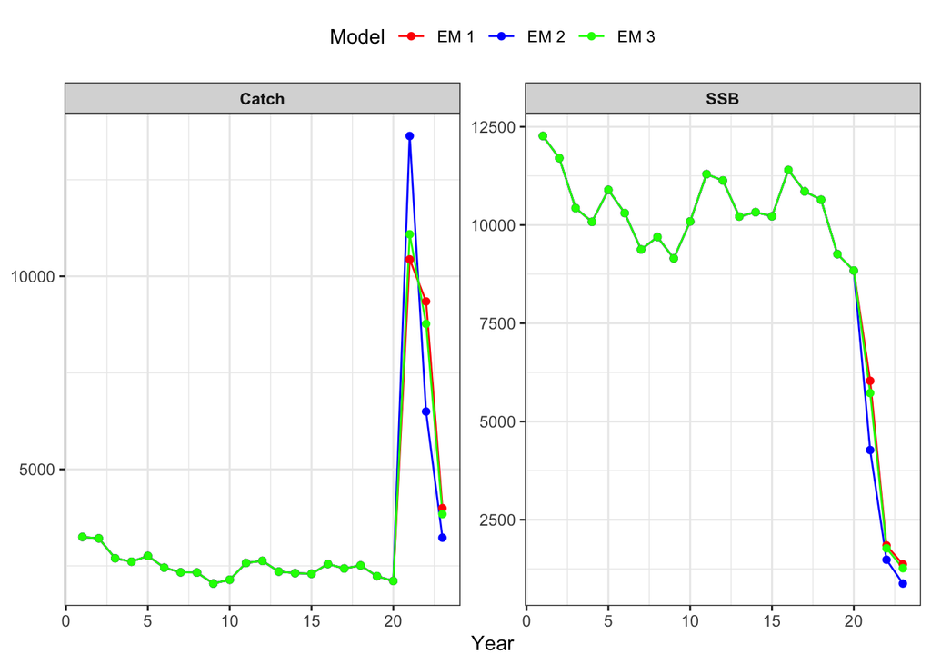

```r
library(ggplot2)
library(dplyr)
library(tidyr)
yrs <- 1:23

# Create dataframe
df <- data.frame(
  Year = yrs,
  SSB_EM1 = mods[[1]]$om$rep$SSB[1:23,1],
  SSB_EM2 = mods[[2]]$om$rep$SSB[1:23,1],
  SSB_EM3 = mods[[3]]$om$rep$SSB[1:23,1],
  Catch_EM1 = mods[[1]]$om$rep$pred_catch[1:23,1],
  Catch_EM2 = mods[[2]]$om$rep$pred_catch[1:23,1],
  Catch_EM3 = mods[[3]]$om$rep$pred_catch[1:23,1]
)

# Convert to long format
plot_df <- df |>
  pivot_longer(-Year) |>
  separate(name, into = c("Variable","Model"), sep = "_")

plot_df$Model <- factor(plot_df$Model,
                        levels = c("EM1","EM2","EM3"),
                        labels = c("EM 1","EM 2","EM 3"))

# Plot
ggplot(plot_df, aes(Year, value, color = Model)) +
  geom_line() +
  geom_point() +
  facet_wrap(~Variable, scales = "free_y") +
  scale_color_manual(values = c("red","blue","green")) +
  labs(
    x = "Year",
    y = NULL
  ) +
  theme_bw() +
  theme(
    strip.text = element_text(face = "bold"),
    legend.position = "top"
  )
```

Same results as vignette using the official SPASAM.MSE, all good.

OK, now try this with a local build of SPASAM.MSE from my fork that has an updated `advice_fn.R` file

First I’m rerunning the above code to ensure I haven’t broken the existing functions.

Still the same results, good.

Now add HCR 4

## Some notes on HCR 4

The MAFMC risk policy and control rule require estimation both of stock B status and OFL based on an F reference point to estimate ABC

The Mid-Atlantic ABC control rule is based on the MAFMC risk policy for probability of overfishing, pstar, combined with the uncertainty in the OFL, OFL CV. It was updated in 2020 to include higher risk tolerance at high stock size.

```r
riskpol <- data.frame(Bfrac = c(0, 0.1, 1.0, 1.5, 2.5),
                      Current = c(0, 0, 0.45, 0.49, 0.49),
                      Pre2020 = c(0, 0, 0.4, 0.4, 0.4)
)

riskpol <- riskpol %>%
  pivot_longer(-Bfrac, names_to = "pstar")

p1 <- ggplot2::ggplot(riskpol, aes(x=Bfrac, y=value, linetype = pstar)) +
  geom_path(show.legend = TRUE) +
  theme_minimal() +
  xlab("B/Bmsy") +
  ylab("p*") +
  labs(linetype = "Policy")+
  theme(legend.position="bottom")


#print(p1, vp=grid::viewport(gp=grid::gpar(cex=1.5)))
```

```r
ABCprop <- data.frame(Bfrac = seq(0, 2.5, 0.01)) %>%
  dplyr::mutate(pstar = case_when(Bfrac <= 0.1 ~ 0,
                                  Bfrac > 0.1 & Bfrac <= 1.0 ~ (Bfrac-0.1)*((0.45-0)/(1-0.1)) ,
                                  Bfrac > 1.0 & Bfrac <= 1.5 ~ (Bfrac-1.0)*((0.49-0.45)/(1.5-1))+0.45,
                                  Bfrac > 1.5 ~ 0.49)) %>%
  dplyr::mutate("CV=60%" = qlnorm(pstar, log(1), log(0.60 + 1)),
                "CV=100%" = qlnorm(pstar, log(1), log(1.00 + 1)),
                "CV=150%" = qlnorm(pstar, log(1), log(1.50 + 1))) %>%
  pivot_longer(-c(Bfrac, pstar), names_to = "CVlevel")


p2 <- ggplot2::ggplot(ABCprop, aes(x=Bfrac, y=value, colour=CVlevel)) +
  geom_line()+
  theme_minimal() +
  xlab("B/Bmsy") +
  ylab("ABC/OFL proportion") +
  labs(colour = "OFL CV") +
  theme(legend.position="bottom")

#print(p2, vp=grid::viewport(gp=grid::gpar(cex=1.5)))
```

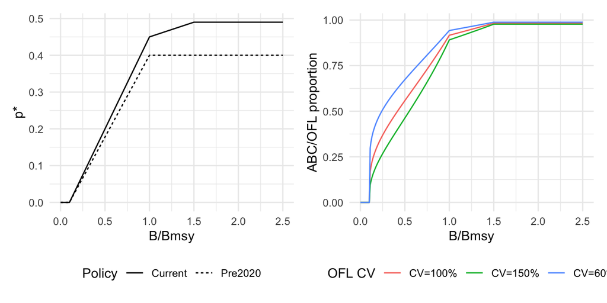

```r
library(patchwork)
p1 + p2
```

In WHAM the ABC can be used in projection as an input catch, but it is needed for each projection year, requiring multiple iterative projections.

My first attempts worked for 1 year projections but we would like more flexibility.

The NEFSC has some [code that does multiyear projections for WHAM models](https://github.com/NEFSC/READ-PDB-COLLABORATIONS/blob/main/Reference-Points-and-Projections/P-star.basic.model.R) which was generalized for use here.

```r
# from https://github.com/NEFSC/READ-PDB-COLLABORATIONS/blob/main/Reference-Points-and-Projections/P-star.basic.model.R

# there are separate functions to estimate Pstar and ABC
# this is the loop to fill a catch vector for projection in WHAM

# Specify the model and projection years
  model.years <- mod$years
  proj.years <- c((tail(model.years,1)+1):(tail(model.years,1)+projyr))

  # Empty variables to collect catch and pstar values
  catch.proj <- rep(0,projyr)

  # Catch in the first year of projections is specified
  catch.proj[1] <- catch.year1

  if(projyr>1)
  {  for(i in 1:(projyr-1))
    {
      # Tell WHAM to do projection based on catch in first i years ('5') and Fmsy proxy ('3') in following years
      proj_F_opt <- c(rep(5,i),rep(3,projyr-i))
      mod.proj <- project_wham(mod, proj.opts = list(n.yrs = projyr,proj_F_opt = proj_F_opt, proj_Fcatch = catch.proj), check.version = F)

      # Get OFL, SSB, and SSB ratio (relative to SSBMSY)
      ofl <- tail(apply(mod.proj$rep$pred_catch,1,sum),projyr)[i+1]
      ssb <- tail(apply(mod.proj$rep$SSB,1,sum),projyr)[i]
      ssbratio <- ssb/SSBmsy

      # Calculate catch from p* code
      catch <- ABC(ofl,ssbratio,CV)

      # As long as its not the terminal year, add the abc catch to catch vector and repeat
      if(i<projyr)
      {
        catch.proj[i+1] <- catch
        if(!is.null(avg.abc)) catch.proj[i+1] <- avg.abc
      }
    }
  }

  # Conduct one last projection to get F and SSB resultant from final ABC
  proj_F_opt <- c(rep(5,projyr))
  mod.proj <- project_wham(mod, proj.opts = list(n.yrs = projyr,proj_F_opt = proj_F_opt, proj_Fcatch = catch.proj), check.version = F)

  # Return the final projection model
  return(mod.proj)
```

The new `advice_fun.R` with the MAFMC risk policy plus HCR is here: https://github.com/sgaichas/SPASAM.MSE/blob/main/R/advice_fn.R

### EM4 is all one area for stock and fleets, MAFMC risk policy and HCR

```r
hcr <- list()
hcr$hcr.type <- 4
hcr$hcr.opts <- list(use_FXSPR = TRUE) #defaults

# Error in `advice_fn()`: length of proj.catch is not = number of projection years
# see if it can do one year projection first
#assess.interval <- 1

# it can, we need to fill the catch vector with assess.interval catches by projecting OFL based on ABC for each previous year
# the advice_fn needs to loop over years for this one?

mods[[4]] = loop_through_fn(om = om_with_data,
                            em_info = info,
                            random = random,
                            sel_em = sel_em,
                            NAA_re_em = NAA_re_em,
                            move_em = NULL,
                            age_comp_em = "logistic-normal-miss0",
                            em.opt = list(separate.em = TRUE, separate.em.type = 1, do.move = FALSE, est.move = FALSE),
                            aggregate_catch_info = list(n_fleets = 1, fleet_pointer = c(1,1), use_catch_weighted_waa = TRUE, catch_Neff = 100, catch_cv = 0.1),
                            aggregate_index_info = list(n_indices = 1, index_pointer = c(1,1), use_catch_weighted_waa = TRUE, index_Neff = 100, index_cv = 0.1),
                            hcr = hcr,
                            assess_years = assess.years,
                            assess_interval = assess.interval,
                            base_years = base.years,
                            year.use = 20,
                            seed = 123)
```

```
##
## Now conducting stock assessment for year 20
```

```
## Using user-specified WAA array. WAA can be time-varying.
```

```
##
##   --------------------
##
##   IMPORTANT!!!!
##
##   For the current version of WHAM, if WAA pointers are specified (i.e., WAA differs across fleets, indices, or stocks),
##
##   they need to be updated *after* prepare_wham_input(). Otherwise, a global WAA will be applied to all components.
##
##   --------------------
##
```

```
##
##   --------------------
##   IMPORTANT!!!!
##
##   For the current version of WHAM:
##
##   - If CV and effective sample size for **catch** vary over years,
##   or if some years have missing aggregate or age composition data for **catch**,
##   you must update these inputs *after* prepare_wham_input()
##   using the update_input_catch_info() function.
##
##   - If CV and effective sample size for **indices** vary over years,
##   or if some years have missing aggregate or age composition data for **indices**,
##   you must update these inputs *after* prepare_wham_input()
##   using the update_input_index_info() function.
##
##   Otherwise, WHAM will assume constant CV/sample size and complete data across all years.
##   --------------------
##
```

```
##
## --Creating input---------------------------------------------------------------------------------------------------------------------
```

```
## basic_info done
```

```
## catch done
```

```
## indices done
```

```
## WAA done
```

```
## NAA done
```

```
## q done
```

```
## selectivity done
```

```
## age_comp done
```

```
## F done
```

```
## M done
```

```
## move done
```

```
## osa_obs done
```

```
## --Input Complete--------------------------------------------------------------------------------------------------------------------
```

[output not shown]

```
##
##
##     --------------------
##
##     IMPORTANT!!!
##
##     WAA pointers are updated!
##
##     --------------------
##
```

```
##
## Now fitting assessment model...
```

```
## Using stats::nlminb for optimization with these control parameters:
```

```
## iter.max: 1000
## eval.max: 1000
```

```
##
## Now checking convergence of assessment model...
##
## Assessment model is converged.
##
## Now using the EM to project catch...
##
## Harvest Control Rule type 4
## SSB_t / SSB_XSPR = 1.421 -> pstar = 0.48; OFL = 27265.870
## SSB_t / SSB_XSPR = 1.190 -> pstar = 0.47; OFL = 23301.292
## SSB_t / SSB_XSPR = 1.216 -> pstar = 0.47; OFL = 23844.105
## Final Projection Options:
##  n.yrs: 3
##  use.last.F: FALSE
##  use.avg.F: FALSE
##  use.FXSPR: FALSE
##  use.FMSY: FALSE
##  avg.yrs: 16, 17, 18, 19, 20
##  cont.ecov: TRUE
##  use.last.ecov: FALSE
##  cont.M.re: FALSE
##  cont.L.re: FALSE
##  proj.catch: 26502.4851487605, 21933.1863659308, 22524.8192760094
##
## Projected catch from assessment model is
##          [,1]
## [1,] 26502.49
## [2,] 21933.19
## [3,] 22524.82
##
## Now allocating catch...
##
## Now generating catch advice...
##          Fleet_1  Fleet_2
## Year_21 13251.24 13251.24
## Year_22 10966.59 10966.59
## Year_23 11262.41 11262.41
##
## Now calculating F at age in the OM given the catch advice...
##
```

[output cut: 16 more lines]

```
## Now simulating data for year 22
##
## Now projecting data for years after 22
##
## Now calculating fleet-specific F in year 23
##
## Fishing mortality is 10, 0.916130935363033
##
## Now updating F in OM for year 23
##
## Now simulating data for year 23
##
## Now projecting data for years after 23
## Please ignore Warning in check_projF(proj_mod).
## Total Runtime =  23.7888
```

### EM5 is all one area for stock and fleets, MAFMC risk policy and HCR with 200% OFL CV

At B>Bmsy this wont make much difference but does result in slightly lower catch advice as predicted

```r
hcr <- list()
hcr$hcr.type <- 4
hcr$hcr.opts <- list(use_FXSPR = TRUE, OFL_CV = 2.0) #defaults but double OFL CV

# Error in `advice_fn()`: length of proj.catch is not = number of projection years
# see if it can do one year projection first
#assess.interval <- 1

# it can, we need to fill the catch vector with assess.interval catches by projecting OFL based on ABC for each previous year
# the advice_fn needs to loop over years for this one?

mods[[5]] = loop_through_fn(om = om_with_data,
                            em_info = info,
                            random = random,
                            sel_em = sel_em,
                            NAA_re_em = NAA_re_em,
                            move_em = NULL,
                            age_comp_em = "logistic-normal-miss0",
                            em.opt = list(separate.em = TRUE, separate.em.type = 1, do.move = FALSE, est.move = FALSE),
                            aggregate_catch_info = list(n_fleets = 1, fleet_pointer = c(1,1), use_catch_weighted_waa = TRUE, catch_Neff = 100, catch_cv = 0.1),
                            aggregate_index_info = list(n_indices = 1, index_pointer = c(1,1), use_catch_weighted_waa = TRUE, index_Neff = 100, index_cv = 0.1),
                            hcr = hcr,
                            assess_years = assess.years,
                            assess_interval = assess.interval,
                            base_years = base.years,
                            year.use = 20,
                            seed = 123)
```

```
##
## Now conducting stock assessment for year 20
```

```
## Using user-specified WAA array. WAA can be time-varying.
```

```
##
##   --------------------
##
##   IMPORTANT!!!!
##
##   For the current version of WHAM, if WAA pointers are specified (i.e., WAA differs across fleets, indices, or stocks),
##
##   they need to be updated *after* prepare_wham_input(). Otherwise, a global WAA will be applied to all components.
##
##   --------------------
##
```

```
##
##   --------------------
##   IMPORTANT!!!!
##
##   For the current version of WHAM:
##
##   - If CV and effective sample size for **catch** vary over years,
##   or if some years have missing aggregate or age composition data for **catch**,
##   you must update these inputs *after* prepare_wham_input()
##   using the update_input_catch_info() function.
##
##   - If CV and effective sample size for **indices** vary over years,
##   or if some years have missing aggregate or age composition data for **indices**,
##   you must update these inputs *after* prepare_wham_input()
##   using the update_input_index_info() function.
##
##   Otherwise, WHAM will assume constant CV/sample size and complete data across all years.
##   --------------------
##
```

```
##
## --Creating input---------------------------------------------------------------------------------------------------------------------
```

```
## basic_info done
```

```
## catch done
```

```
## indices done
```

```
## WAA done
```

```
## NAA done
```

```
## q done
```

```
## selectivity done
```

```
## age_comp done
```

```
## F done
```

```
## M done
```

```
## move done
```

```
## osa_obs done
```

```
## --Input Complete--------------------------------------------------------------------------------------------------------------------
```

[output not shown]

```
##
##
##     --------------------
##
##     IMPORTANT!!!
##
##     WAA pointers are updated!
##
##     --------------------
##
```

```
##
## Now fitting assessment model...
```

```
## Using stats::nlminb for optimization with these control parameters:
```

```
## iter.max: 1000
## eval.max: 1000
```

```
##
## Now checking convergence of assessment model...
##
## Assessment model is converged.
##
## Now using the EM to project catch...
##
## Harvest Control Rule type 4
## SSB_t / SSB_XSPR = 1.421 -> pstar = 0.48; OFL = 27265.870
## SSB_t / SSB_XSPR = 1.193 -> pstar = 0.47; OFL = 23358.913
## SSB_t / SSB_XSPR = 1.225 -> pstar = 0.47; OFL = 24026.010
## Final Projection Options:
##  n.yrs: 3
##  use.last.F: FALSE
##  use.avg.F: FALSE
##  use.FXSPR: FALSE
##  use.FMSY: FALSE
##  avg.yrs: 16, 17, 18, 19, 20
##  cont.ecov: TRUE
##  use.last.ecov: FALSE
##  cont.M.re: FALSE
##  cont.L.re: FALSE
##  proj.catch: 26065.8803216767, 21235.4099148758, 21995.0443500565
##
## Projected catch from assessment model is
##          [,1]
## [1,] 26065.88
## [2,] 21235.41
## [3,] 21995.04
##
## Now allocating catch...
##
## Now generating catch advice...
##          Fleet_1  Fleet_2
## Year_21 13032.94 13032.94
## Year_22 10617.70 10617.70
## Year_23 10997.52 10997.52
##
## Now calculating F at age in the OM given the catch advice...
##
```

[output cut: 16 more lines]

```
## Now simulating data for year 22
##
## Now projecting data for years after 22
##
## Now calculating fleet-specific F in year 23
##
## Fishing mortality is 10, 0.845225835257803
##
## Now updating F in OM for year 23
##
## Now simulating data for year 23
##
## Now projecting data for years after 23
## Please ignore Warning in check_projF(proj_mod).
## Total Runtime =  23.88592
```

## Compare performance with MAFMC HCR

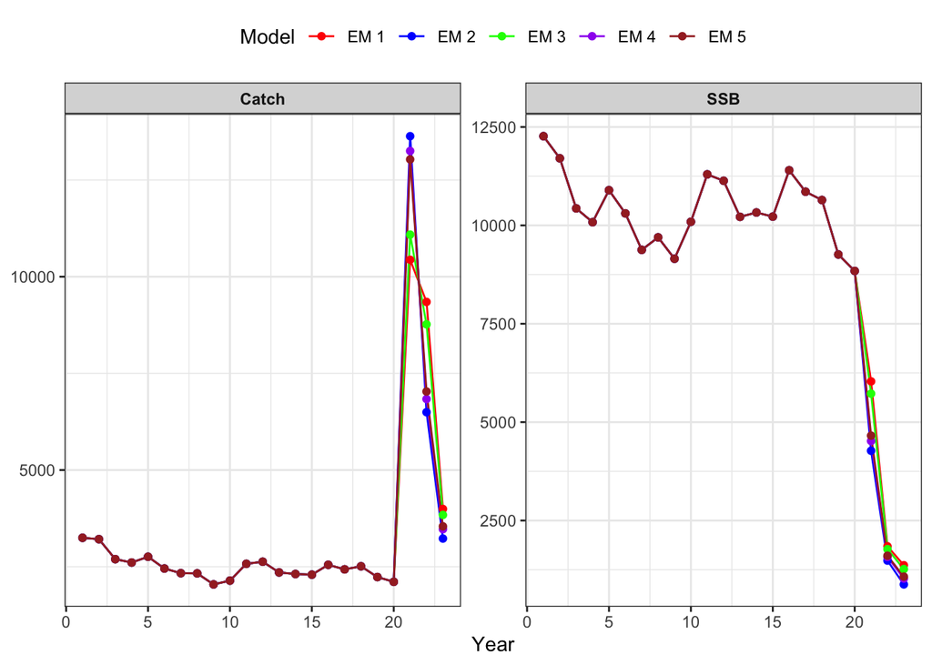

```r
library(ggplot2)
library(dplyr)
library(tidyr)

yrs <- 1:23

# Create dataframe
df <- data.frame(
  Year = yrs,
  SSB_EM1 = mods[[1]]$om$rep$SSB[1:23,1],
  SSB_EM2 = mods[[2]]$om$rep$SSB[1:23,1],
  SSB_EM3 = mods[[3]]$om$rep$SSB[1:23,1],
  SSB_EM4 = mods[[4]]$om$rep$SSB[1:23,1],
  SSB_EM5 = mods[[5]]$om$rep$SSB[1:23,1],
  Catch_EM1 = mods[[1]]$om$rep$pred_catch[1:23,1],
  Catch_EM2 = mods[[2]]$om$rep$pred_catch[1:23,1],
  Catch_EM3 = mods[[3]]$om$rep$pred_catch[1:23,1],
  Catch_EM4 = mods[[4]]$om$rep$pred_catch[1:23,1],
  Catch_EM5 = mods[[5]]$om$rep$pred_catch[1:23,1]
)

# Convert to long format
plot_df <- df |>
  pivot_longer(-Year) |>
  separate(name, into = c("Variable","Model"), sep = "_")

plot_df$Model <- factor(plot_df$Model,
                        levels = c("EM1","EM2","EM3", "EM4", "EM5"),
                        labels = c("EM 1","EM 2","EM 3", "EM 4", "EM 5"))

# Plot
ggplot(plot_df, aes(Year, value, color = Model)) +
  geom_line() +
  geom_point() +
  facet_wrap(~Variable, scales = "free_y") +
  scale_color_manual(values = c("red","blue","green", "purple", "brown")) +
  labs(
    x = "Year",
    y = NULL
  ) +
  theme_bw() +
  theme(
    strip.text = element_text(face = "bold"),
    legend.position = "top"
  )
```

## Make sure it runs for more than one assessment cycle

### EM6 is all one area for stock and fleets, MAFMC risk policy and HCR for 3 cycles

Start over with MSE_years = 9

```r
year_start  <- 1
year_end    <- 20
MSE_years   <- 9

info <- generate_basic_info(
  n_stocks = 2,
  n_regions = 2,
  n_indices = 2,
  n_fleets = 2,
  n_seasons = 1,
  base.years = year_start:year_end,
  n_feedback_years = MSE_years,
  life_history = "medium",
  n_ages = 12
)

basic_info = info$basic_info
catch_info = info$catch_info
index_info = info$index_info
F_info     = info$F

basic_info <- generate_NAA_where(basic_info, move.type = 2)
move <- generate_move(
  basic_info = basic_info,
  move.type = 2,
  move.rate = c(0.3, 0.1),
  move.re = "constant"
)

n_stocks  <- as.integer(basic_info['n_stocks'])
n_regions <- as.integer(basic_info['n_regions'])
n_fleets  <- as.integer(basic_info['n_fleets'])
n_indices <- as.integer(basic_info['n_indices'])
n_ages    <- as.integer(basic_info['n_ages'])

fleet_pars <- c(5, 1)
index_pars <- c(2, 1)
sel <- list(
  model = rep("logistic", n_fleets + n_indices),
  initial_pars = c(rep(list(fleet_pars), n_fleets), rep(list(index_pars), n_indices))
)

sigma      <- "rec+1"
re_cor     <- "iid"
ini.opt    <- "equilibrium"
Rec_sig    <- 0.5
NAA_sig    <- 0.2

sigma_vals <- array(NAA_sig, dim = c(n_stocks, n_regions, n_ages))
sigma_vals[,,1] <- Rec_sig

log_N1    <- rep(10, n_stocks)
log_N1[1] <- log(exp(10) * 2)
N1_pars   <- generate_ini_N1(basic_info, ini.opt, log_N1)

mean_rec_par <- lapply(1:n_stocks, function(i) exp(log_N1[i]))

NAA_re <- list(
  N1_model = rep(ini.opt, n_stocks),
  sigma = rep(sigma, n_stocks),
  cor = rep(re_cor, n_stocks),
  recruit_model = 2,
  recruit_pars = mean_rec_par,
  sigma_vals = sigma_vals,
  N1_pars = N1_pars
)

input <- prepare_wham_input(
  basic_info = basic_info,
  selectivity = sel,
  NAA_re = NAA_re,
  move = move,
  catch_info = catch_info,
  index_info = index_info,
  F = F_info,
  age_comp = "logistic-normal-miss0"
)


random <- input$random
input$random <- NULL
om <- fit_wham(input, do.fit = FALSE, do.brps = TRUE, MakeADFun.silent = TRUE)

assess.interval <- 3
base.years      <- year_start:year_end
terminal.year   <- tail(base.years, 1)
assess.years    <- seq(terminal.year, tail(om$years, 1) - assess.interval, by = assess.interval)


n_stocks = n_regions = n_fleets = n_indices = 1

sel_em <- list(model=rep("logistic", n_fleets + n_indices),
               initial_pars=c(rep(list(fleet_pars), n_fleets), rep(list(index_pars), n_indices)))

NAA_re_em <- list(N1_model="equilibrium", sigma="rec+1", cor="iid")

hcr <- list()
hcr$hcr.type <- 4
hcr$hcr.opts <- list(use_FXSPR = TRUE) #defaults but double OFL CV


mods[[6]] = loop_through_fn(om = om_with_data,
                            em_info = info,
                            random = random,
                            sel_em = sel_em,
                            NAA_re_em = NAA_re_em,
                            move_em = NULL,
                            age_comp_em = "logistic-normal-miss0",
                            em.opt = list(separate.em = TRUE, separate.em.type = 1, do.move = FALSE, est.move = FALSE),
                            aggregate_catch_info = list(n_fleets = 1, fleet_pointer = c(1,1), use_catch_weighted_waa = TRUE, catch_Neff = 100, catch_cv = 0.1),
                            aggregate_index_info = list(n_indices = 1, index_pointer = c(1,1), use_catch_weighted_waa = TRUE, index_Neff = 100, index_cv = 0.1),
                            hcr = hcr,
                            assess_years = assess.years,
                            assess_interval = assess.interval,
                            base_years = base.years,
                            year.use = 20,
                            seed = 123)
```

This errors out, copied output below

[output not shown]

[output not shown]

[output not shown]

### Does a different HCR also crash? Try 100% FXSPR 3 assessment loops

Yes it also crashes at the same point, calculating fleet specific F in year 24

```r
hcr <- list()
hcr$hcr.type <- 1
hcr$hcr.opts <- list(use_FXSPR = TRUE, percentFXSPR = 100)


mods[[7]] = loop_through_fn(om = om_with_data,
                            em_info = info,
                            random = random,
                            sel_em = sel_em,
                            NAA_re_em = NAA_re_em,
                            move_em = NULL,
                            age_comp_em = "logistic-normal-miss0",
                            em.opt = list(separate.em = TRUE, separate.em.type = 1, do.move = FALSE, est.move = FALSE),
                            aggregate_catch_info = list(n_fleets = 1, fleet_pointer = c(1,1), use_catch_weighted_waa = TRUE, catch_Neff = 100, catch_cv = 0.1),
                            aggregate_index_info = list(n_indices = 1, index_pointer = c(1,1), use_catch_weighted_waa = TRUE, index_Neff = 100, index_cv = 0.1),
                            hcr = hcr,
                            assess_years = assess.years,
                            assess_interval = assess.interval,
                            base_years = base.years,
                            year.use = 20,
                            seed = 123)
```

Output pasted below

[output not shown]